# Propser Loan Data Analysis

## by Jimmy Le

## Preliminary Wrangling

This notebook explores a dataset containing peer-to-peer loan information of approximately 113,000 loans from Prosper Funding LLC.

## Univariate Exploration

### Estimated Return

Let's start by getting a closer look at our feature of intrests beginning with the estimated returns.

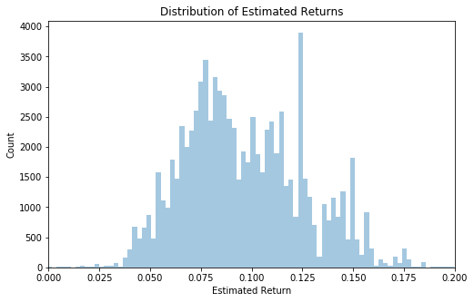

```python
# zoom in on histogram
plt.figure(figsize = [8,5])
sns.distplot(df.EstimatedReturn, kde = False, bins = 200)
plt.xlim(0, .2)
plt.xlabel('Estimated Return')
plt.ylabel('Count')
plt.title('Distribution of Estimated Returns');
```

It also looks like there are some peaks in some standard values such as 5%, 7.5%, 12.5%, and 15%. Most curiously the largest bin falls right around 12.5%.

Let's try to calculate the actual returns and see how they compare to the estimated returns.

### Actual Returns

This section appears to be quite nuanced and required a bit of feature engineering. Let's try to calculate the actual returns by using the remaining loan performance (LP) variables.

To simplify our calculation for exploratory purposes, we will only divide by the original loan amount. We will run into other categorical issues if we try to determine the current rate of return for current loans vs completed loans etc. We may revisit this section to refine our actual returns feature.

[figure not shown]

```python
# multiplot for loan status

variables = ['Current', 'Completed', 'Chargedoff', 'Defaulted']

plt.figure(figsize = [16, 10])

# loop through variables list
for i in range(len(variables)):
    plt.subplot(2, 2, i+1)

    sns.distplot(df.query('LoanStatus == "{}"'.format(variables[i])).ActualReturns,
                 kde = False, bins = 200)

    plt.xlabel('Actual Returns')
    plt.ylabel('Count')
    plt.title(variables[i])

plt.subplot(2, 2, 2)
plt.xlim(.9, 1.8)

plt.suptitle('Distribution of Estimated Returns by Loan Status');
```

### Prosper Credit Grade

Now that we have a high level overview of what the returns on the platform look like, let's see if there is a similar or distribution for the borrower's prosper/credit grade.

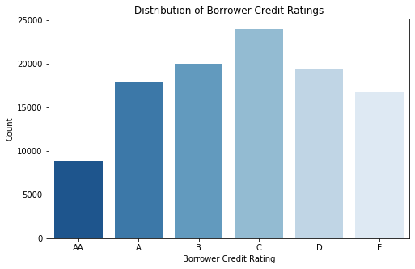

```python
plt.figure(figsize = [8, 5])
sns.countplot(data = df, x = 'ProsperRatingCombined', palette = "Blues_r")
plt.xlabel('Borrower Credit Rating')
plt.ylabel('Count')
plt.title('Distribution of Borrower Credit Ratings');
```

The distribution of credit ratings is skewed to the right which coincides with our observation of estimated return distribution also being skewed to the right

This could mean that for a particular credit rating we have a range of possible estimated returns, let's look into this in our bivariate visualizations.

### Income Range

Let's continue our exploration by looking at a couple of the underwriting features for borrowers to be assigned these Credit Ratings. We'll start with taking a look at Income Ranges.

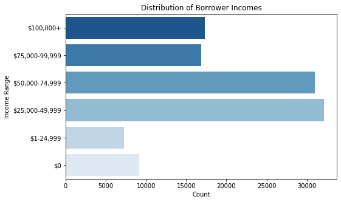

```python
# bar chart
plt.figure(figsize = [8, 5])
sns.countplot(data = df, y = 'IncomeRange', palette = "Blues_r")
plt.ylabel('Income Range')
plt.xlabel('Count')
plt.title('Distribution of Borrower Incomes');
```

Its interesting to see that the number of borrowers for the \$25k-49k range is the same as the \\$50k-74k range. The amount of borrowers in the \$75k-100k range is the same as all borrowers that have an income of over \\$100k.

### Debt to Income Ratio

Of course your income is only part of the picture, let's see what the borrower's Debt to Income Ratio is like. I imagine a creditor wants to make sure you're not overleveraged in the event you have a loss of income and are unable to repay all of your debts.

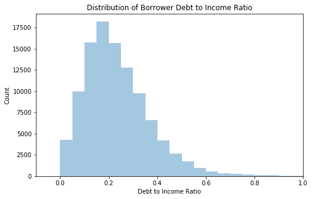

```python
# distribution plot
plt.figure(figsize = [8,5])
sns.distplot(df.DebtToIncomeRatio, kde = False, bins = 200)
plt.xlim(-.1, 1)
plt.xlabel('Debt to Income Ratio')
plt.ylabel('Count')
plt.title('Distribution of Borrower Debt to Income Ratio');
```

### Discuss the distribution(s) of your variable(s) of interest. Were there any unusual points? Did you need to perform any transformations?

To summarize our variables of interest, we looked at income, debt to income ratios, credit ratings, estimated returns and actual returns for the data set.

We saw relatively normal distributions for income, debt to income, credit ratings, and estimated returns. However, trying to calculate the real time actual returns proved to be difficult. We may want to revisit this feature if we are trying to answer a particular question about the data set.

While doing some research for this dataset, I stumbled across a few blog posts discussing how Prosper has updated how they calculate their annualized returns resulting in lower returns.

On the [LendAcademy website](https://www.lendacademy.com/prosper-corrects-annualized-return-calculation/), the authors conlude that:

> In the past p2p lending investors have relied on different ways to calculate returns outside of what the platforms provide. This is because calculating returns is complex and there is no consensus on what method is best.

In the discussion on [LendAcademy](https://www.lendacademy.com/prosper-corrects-annualized-return-calculation/), investors shared their personal anecdotes of their return estimates dropping nearly in half. This can be extremly frustrating when an investor is expecting much higher returns on their investment. Not to mention the invisible opportunity cost of investing their money elsewhere.

### Of the features you investigated, were there any unusual distributions? Did you perform any operations on the data to tidy, adjust, or change the form of the data? If so, why did you do this?

We saw that from our simplified actual returns formula, that the values returned vary greatly between different loan statuses.

To tidy up our visualizations, we combined several rows for different visuals where the categories appeared to be redundant. Such as the income ranges of "Not employed" and "Not displayed" are essentially equivalent to "\$0". For Credit Ratings, Prosper developed their proprietary system after 2009 which resulted in many missing rows. We combined these features to get a complete Credit Rating feature. We also combined the "High Risk", "No Credit", and "E" categories together.

## Bivariate Exploration

### Quantitative vs. Quantitative

First, let's look at the pairwise correlation between the numeric features we are interested in.

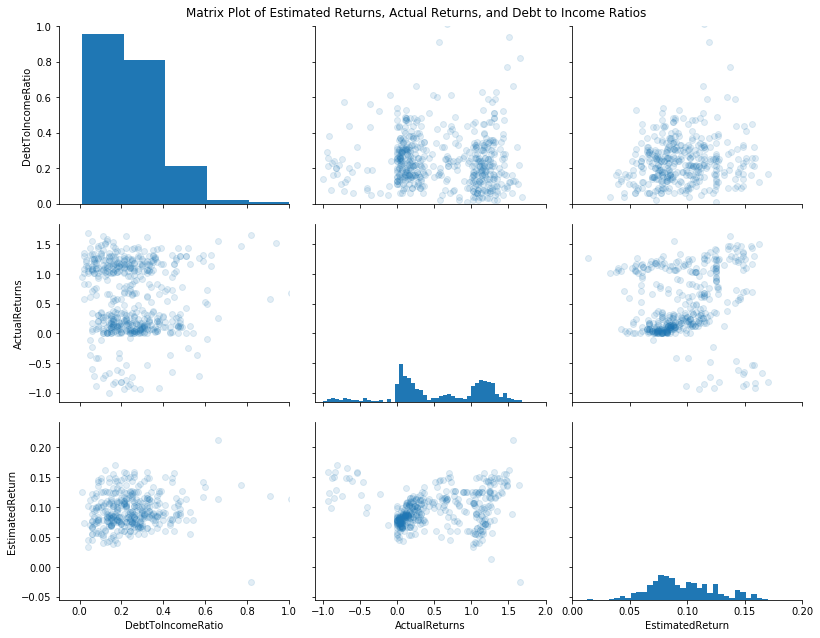

```python
# plot matrix with 0.5% of data points
samples = np.random.choice(df.shape[0], int(df.shape[0]*.005), replace = False)
df_samp = df.loc[samples,:]

# pair grid
g = sns.PairGrid(data = df_samp, vars = numeric_vars, size = 3, aspect = 1.25)
g = g.map_diag(plt.hist, bins = 50)
g.map_offdiag(plt.scatter, alpha = 1/8)

# set axis limits
g.axes[0,0].set_ylim(0,1)
g.axes[0,0].set_xlim(-.1,1)
g.axes[0,1].set_xlim(-1.1,2)
g.axes[0,2].set_xlim(0,.2)

g.fig.suptitle('Matrix Plot of Estimated Returns, Actual Returns, and Debt to Income Ratios')
g.fig.subplots_adjust(top = .95);
```

From the univariate exploration, we have a good undertanding regarding the range of values we can expect. By limiting the axis values, we are able to prevent outliers from skewing the plot. Otherwise, most of the points will appear to be grouped in a vertical line.

Surprisingly, there doesn't appear to be any correlation between the estimated returns and the actual returns we calculated. We may have to investigate further by querying select categories of loan status.

There doesn't appear to be a correlation between any of the other numeric variables either.

You may intuitively expect borrowers with a high debt to income ratio to be riskier and thus have a lower rate of return - but that doesn't seem to be the case.

### Quantitative vs. Qualitative

Let's take a look at how a borrower's income range and credit rating relates to the investor's estimated returns.

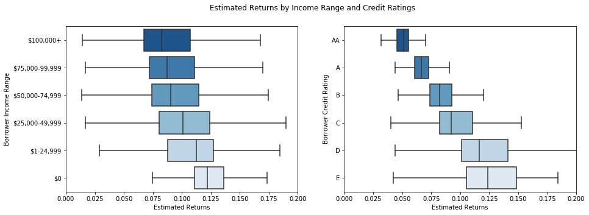

```python
# boxplots
plt.figure(figsize = [15, 5])

plt.subplot(1, 2, 1)
base_color = sns.color_palette()[0]
sns.boxplot(data = df, y = 'IncomeRange', x = 'EstimatedReturn', palette = "Blues_r", showfliers = False)
plt.xlim(0,.2)
plt.ylabel('Borrower Income Range')
plt.xlabel('Estimated Returns')

plt.subplot(1, 2, 2)
base_color = sns.color_palette()[0]
sns.boxplot(data = df, y = 'ProsperRatingCombined', x = 'EstimatedReturn', palette = "Blues_r", showfliers = False)
plt.xlim(0,.2)
plt.ylabel('Borrower Credit Rating')
plt.xlabel('Estimated Returns')

plt.suptitle('Estimated Returns by Income Range and Credit Ratings');
```

From these boxplot, we're able to clearly see that as the borrowers income increases, the median estimated return decreases. The credit rating boxplot shows the trend more clearly, as a borrowers credit rating increases, the median estimated return greatly decreases.

Also, creditors typically compete for these high income borrowers which drive the highest credit rating interest rates down.

It's interesting to see that the width and whiskers of the boxplots shrink as credit rating increases. This suggests that the expected returns for this feature is much more predictable vs the lower credit ratings.

## Qualitative vs. Qualitiative

Let's continue to explore this thread by also plotting the credit score along with the income range.

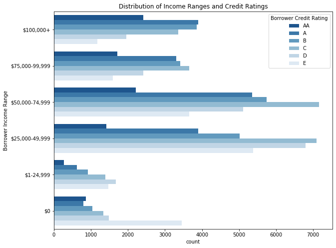

```python
# clustered bar chart
plt.figure(figsize = [10,8])

ax = sns.countplot(data = df, y = 'IncomeRange', hue = 'ProsperRatingCombined',
                   palette = 'Blues_r')

ax.legend(title = 'Borrower Credit Rating')
plt.title('Distribution of Income Ranges and Credit Ratings')
plt.ylabel('Borrower Income Range');
```

From this clustered bar chart, we can see the trend of higher incomes correlate to a higher credit rating qualifying the borrower for the best (lowest) interest rates.

Having an income of \$75k+ doesn't automatically guarantee the best credit ratings. I'm curious to see in the multivariate analysis what other factors play a big role in determining one's credit rating.

Conversely, it also appears that in the \$0 income range, there are a high amount of "AA" loans relative to the \\$1-25k income range. I hypothesize you must have other significant assets or a great history with the platform to receive the highest credit rating without any income!

### Talk about some of the relationships you observed in this part of the investigation. How did the feature(s) of interest vary with other features in the dataset? Did you observe any interesting relationships between the other features (not the main feature(s) of interest)?

From our matrix plot, our numerical features of interest did not reveal any correlation. It was surprising to see that there was no correlation between debt to income ratios, estimated returns, and actual returns.

From our box plots, we saw a trend of median estimated returns decrease as the borrowers income range increased. This makes intuitive sense as borrowers with a higher income can demand the most competetive rates from creditors. The overlap in our boxplot suggests that borrowers in any income range (except \$0) can produce the same estimated return for an investor. The trend between lower estimated returns and higher credit ratings was much more apparent with narrowing quartiles and lower medians.

From our clustered bar chart, we peeled back another layer to look at credit ratings and income ranges. This revealed that the previous trend of high income equating to better credit ratings, however there are some interesting cases where a high number of borrowers with no income qualified for the highest credit ratings. Also, we saw that borrowers with incomes of greater than $75k can still be considered "High Risk" borrowers.

## Multivariate Exploration

The main thing I want to explore in the multivariate exploration is the relationship between income ranges, credit scores, and estimated returns.

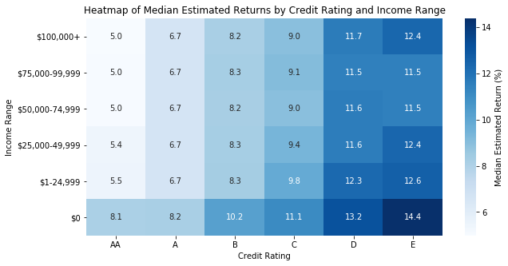

```python
# create a heat map of average estimated returnsb
plt.figure(figsize = [10,5])

cat_med = df.groupby(['ProsperRatingCombined', 'IncomeRange']).median()['EstimatedReturn']*100
cat_med = cat_med.reset_index(name = 'EstimatedReturnMedian')
cat_med = cat_med.pivot(index = 'IncomeRange', columns = 'ProsperRatingCombined', values = 'EstimatedReturnMedian')

sns.heatmap(cat_med, annot = True, fmt = '.1f', cmap = "Blues", cbar_kws = {'label' : 'Median Estimated Return (%)'})
plt.xlabel('Credit Rating')
plt.ylabel('Income Range')
plt.title('Heatmap of Median Estimated Returns by Credit Rating and Income Range');
```

From the heat map we continue to see the trend of lower credit ratings, and lower incomes equate to higher returns. It's interesting to see that the income range does not play a big influence on the estimated returns by credit rating category.

Across the credit ratings 'AA', 'A', and 'B', we observe no difference in the rate of return for income ranges \$1-100k+. However, there is a definite jump in returns for the \\$0 income range across all credit rating categories.

Across the credit ratings 'C', 'D', and 'E', we notice a bit more variability however the median return is still within +- 1% (except the \$0 category).

Since we know that credit ratings are a better indicator of estimated returns, let's see if the status of a loan will allow us to see a correlation between our estimated returns and actual returns.

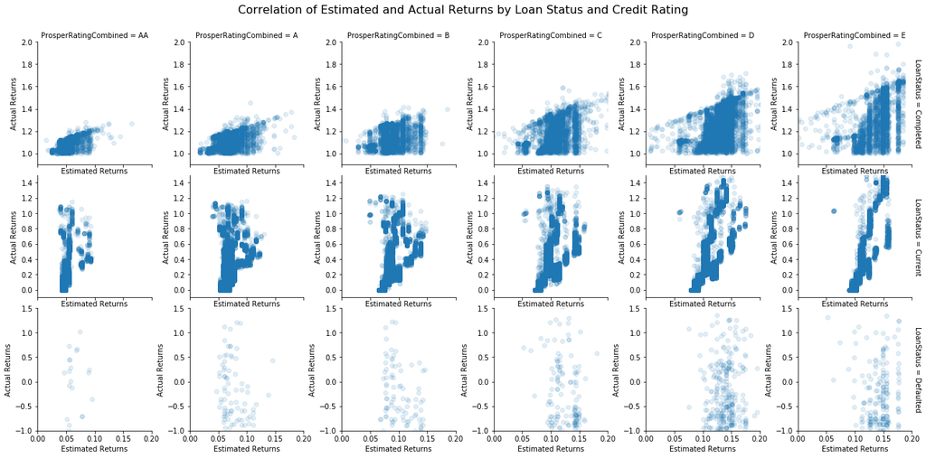

```python
# create scatter plot across credit ratings and loan status
g = sns.FacetGrid(data = df, col = 'ProsperRatingCombined', row_order = ['Completed', 'Current', 'Defaulted'],
                  row = 'LoanStatus', margin_titles = True, xlim = (0,.2), sharey = False)
g.map(plt.scatter, 'EstimatedReturn', 'ActualReturns', alpha = 1/8)

# set different y axes for different loan statuses
for i, ax in enumerate(g.axes.flat):
    if i < 6:
        ax.set_ylim(.9, 2)
    elif i < 12:
        ax.set_ylim(-.1, 1.5)
    else:
        ax.set_ylim(-1, 1.5)

g.set(xlabel = 'Estimated Returns', ylabel = 'Actual Returns')

g.fig.suptitle('Correlation of Estimated and Actual Returns by Loan Status and Credit Rating', size = 16)
g.fig.subplots_adjust(top = .9);
```

### Talk about some of the relationships you observed in this part of the investigation. Were there features that strengthened each other in terms of looking at your feature(s) of interest? Were there any interesting or surprising interactions between features?

I simplified the plot a bit by only looking at three loan statuses: Completed, Current, and Defaulted.

For loans that are defaulted, there doesn't appear to be any correlation between the predicted estimated return and the actual return of the loan.

For loans that are current, there appears to be a linear relationship between the estimated and actual returns! Recall that during our bivariate exploration we were unable to see the trend as all of the loan status were lumped together.

For loans that are completed, wee can se there is a clear linear relationship with estimated returns and actual returns. However, it also appears this linear line is *shaded* as well. This means that no matter what the estimated return for the loan was, there is a chance the loan always returns the full balance. This may occur if a borrower received the loan and quickly paid it off in a couple of months, minimizing the amount of interest paid.